# ggmotif

Xiang Li

2022-06-30

## ggmotif: An R Package for the extraction and visualization of motifs from MEME software

[figure not shown]

MEME Suit is a most used tool to identify motifs within deoxyribonucleic acid (DNA) or protein sequences. However, the results generated by the MEME Suit are saved using file formats, *.xml* and *.txt,* that are difficult to read, visualize or integrate with other wide used phylogenetic tree packages such as *ggtree*. To overcome this problem, we developed the *ggmotif* R package that provides a set of easy-to-use functions that can be used to facilitate the extraction and visualization of motifs from the results files generated by the MEME Suit. *ggmotif* can extract the information of the location of motif(s) on the corresponding sequence(s) from the *.xml* format file and visualize it. Additionally, the data extracted by *ggmotif* can be easily integrated with the phylogenetic data generated by *ggtree*. On the other hand, *ggmotif* can get the sequence of each motif from the *.txt* format file and draw the sequence logo with the function *ggseqlogo* from *ggseqlogo* R package.

## Authors

Xiang LI

College of Plant Protection, Yunnan Agricultural University

https://www.web4xiang.top/

## Identification of motifs

The demo data, the AP2 gene family of *Arabidopsis thaliana*, was downloaded from [Plant Transcription Factor Database](http://planttfdb.gao-lab.org/family.php?sp=Ath&fam=AP2). The latest version MEME, v5.4.1, was used search motifs from the demo data using the fellow code:

```
meme ara.fa -protein -o meme_out -mod zoops -nmotifs 10 -minw 4 -maxw 7 -objfun classic -markov_order 0
```

The output files, `html`file, `txt` file and `xml` file, can be found at [GitHub](https://github.com/lixiang117423/ggmotif/tree/main/ggmotif/inst/demo_data).

## Construction of phylogenetic tree

clustalo (V1.2.4) and FastTree (V2.1.10) were used to align the sequences and construct the phylogenetic tree.

```
clustalo -i ara.fa > ara.aligned.fa
FastTree ara.aligned.fa > ara.twk
```

The output files can be found at [GitHub](https://github.com/lixiang117423/ggmotif/tree/main/ggmotif/inst/demo_data).

## Installation and loading

- Install the latest developmental version from [GitHub](https://github.com/lixiang117423/ggmotif) as follow:

```r
if(!require(devtools)) install.packages("devtools")
devtools::install_github("lixiang117423/ggmotif")
```

- Or install from [CRAN](https://CRAN.R-project.org/package=ggmotif) as follow:

```r
install.packages("ggmotif")
```

- Loading package

```r
library(ggmotif)
```

## Parse motif information from MEME results

The results generated by MEME Suit include a lot of files, including figures of each motif and three other files, a `html`file, a `txt`file and a `xml` file. The `html` file contain some figures of motifs. The `txt` file is for the sequences’ information and the `xml` for other information including position, length, p-value and so on.

The main function of `ggmotif` is to parse the information and plot the position of each motif on the corresponding sequences.

## Parse information

### information of sequences of motifs

```r
filepath <- system.file("examples", "meme.txt", package = "ggmotif")
motif.info <- getMotifFromMEME(data = filepath, format="txt")
```

### information of other detail information of motifs

```r
filepath <- system.file("examples", "meme.xml", package="ggmotif")
motif.info.2 <- getMotifFromMEME(data = filepath, format="xml")
```

## Plot location

The figures from MEME only contain the location. It is difficult to combine the location figure to the corresponding phylogenetic tree. In `ggmotif`, the function `motifLocation` can visualize the location of each motif on its corresponding sequences, almost same as the `html` file. If user have the corresponding phylogenetic tree, the function can combine the tree and the location.

### Without tree

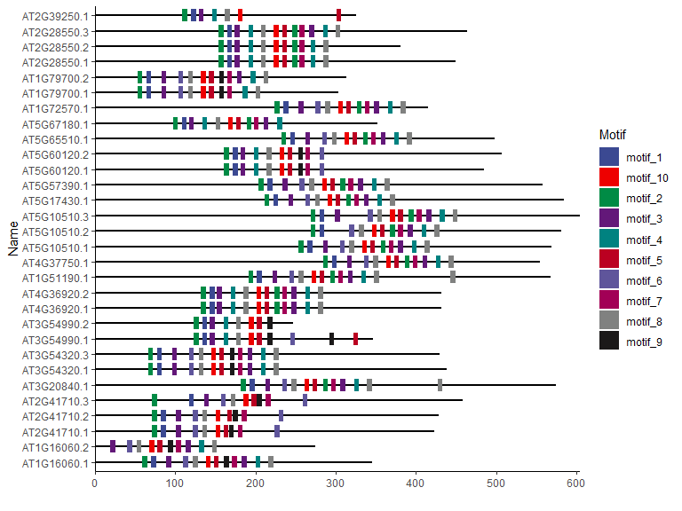

```r
filepath <- system.file("examples", "meme.xml", package = "ggmotif")
motif_extract <- getMotifFromMEME(data = filepath, format="xml")
motif_plot <- motifLocation(data = motif_extract)
motif_plot +
  ggsci::scale_fill_aaas()
```

```r
ggplot2::ggsave(filename = "1.png", width = 6, height = 6, dpi = 300)
```

### With tree

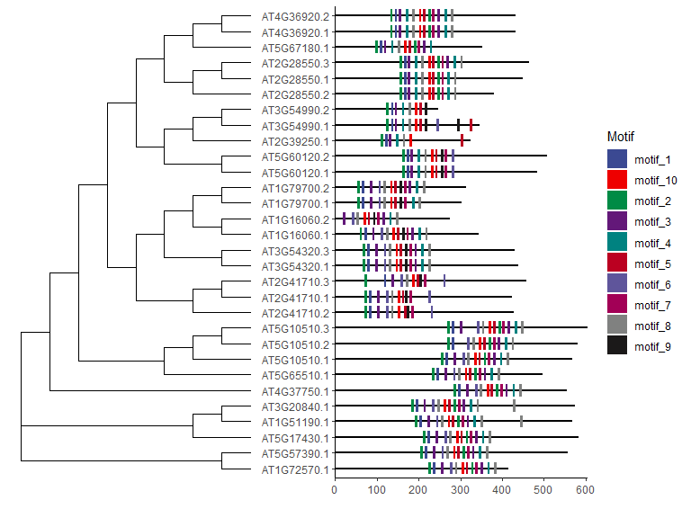

```r
filepath <- system.file("examples", "meme.xml", package = "ggmotif")
treepath <- system.file("examples", "ara.nwk", package="ggmotif")
motif_extract <- getMotifFromMEME(data = filepath, format="xml")
motif_plot <- motifLocation(data = motif_extract, tree = treepath)
motif_plot +
  ggsci::scale_fill_aaas()
```

```r
ggplot2::ggsave(filename = "2.png", width = 8, height = 6, dpi = 300)
```

If other information of phylogenetic tree is available, the parameter `tree.anno` can be used to plot the tip_point of phylogenetic tree.

```r
library(tidyverse)
```

[figure not shown]

```r
filepath <- system.file("examples", "meme.xml", package = "ggmotif")
treepath <- system.file("examples", "ara.nwk", package="ggmotif")

motif_extract <- getMotifFromMEME(data = filepath, format="xml")
tree.anno.path <- system.file("examples", "tree.anno.txt", package="ggmotif")
tree.anno = data.table::fread(tree.anno.path) %>%
  dplyr::mutate(Group = as.character(Group))

motif_plot <- motifLocation(data = motif_extract, tree = treepath, tree.anno = tree.anno)
motif_plot +
  ggsci::scale_fill_aaas()
```

## show motif(s)

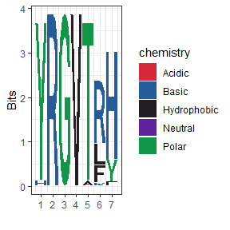

```r
library(tidyverse)
library(ggseqlogo)

filepath <- system.file("examples", "meme.txt", package = "ggmotif")
motif.info <- getMotifFromMEME(data = filepath, format = "txt")

# show one motif
motif.info %>%
  dplyr::select(2, 4) %>%
  dplyr::filter(motif.num == "Motif.2") %>%
  dplyr::select(2) %>%
  ggseqlogo::ggseqlogo() +
  theme_bw()
```

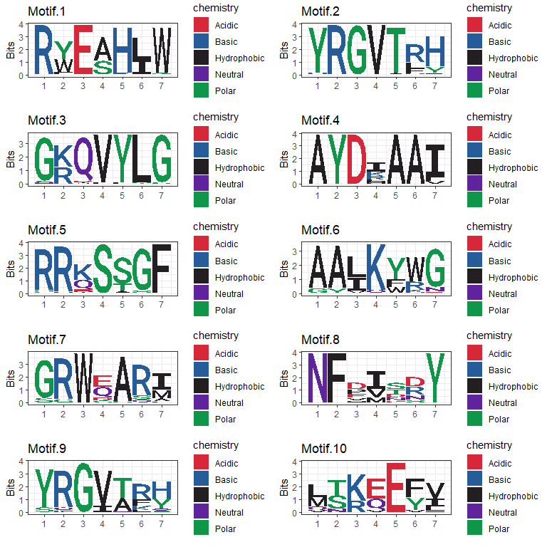

```r
filepath <- system.file("examples", "meme.txt", package = "ggmotif")
motif.info <- getMotifFromMEME(data = filepath, format = "txt")

# show all motif
plot.list <- NULL

for (i in unique(motif.info$motif.num)) {
  motif.info %>%
    dplyr::select(2, 4) %>%
    dplyr::filter(motif.num == i) %>%
    dplyr::select(2) %>%
    ggseqlogo::ggseqlogo() +
    labs(title = i) +
    theme_bw() -> plot.list[[i]]
}

cowplot::plot_grid(plotlist = plot.list, ncol = 2)
```

## Compare with other tools

The widely used R packages `memes` and `universalmotif` can process `.txt` files generated by MEME, but the extracted information does not have the location information of motifs.

```r
library(tidyverse)
library(memes)

meme.res = memes::importMeme("meme.txt",combined_sites = TRUE)
```

```
## Could not find strand info, assuming +.
```

```r
# table from memes::importMeme function
meme.res[["meme_data"]] %>%
  dplyr::select_if(~ !any(is.na(.))) %>%
  dplyr::select(-bkg,-motif)
```

```
##       name altname consensus alphabet strand  icscore nsites     eval type
## 1  RYEAHJW  MEME-1   RYEAHJW       AA      + 24.53271     30 2.6e-138  PPM
## 2  YRGVTRH  MEME-2   YRGVTRH       AA      + 25.34900     30 1.3e-124  PPM
## 3  GKQVYLG  MEME-3   GKQVYLG       AA      + 25.46267     30 1.2e-115  PPM
## 4  AYDIAAI  MEME-4   AYDIAAI       AA      + 25.14833     30 1.6e-114  PPM
## 5  RRKSSGF  MEME-5   RRKSSGF       AA      + 24.54460     30  1.6e-87  PPM
## 6  AAJKYWG  MEME-6   AALKYWG       AA      + 22.19454     28  8.1e-84  PPM
## 7  GRWZARI  MEME-7   GRWEARI       AA      + 22.76200     26  4.3e-82  PPM
## 8  NFDISDY  MEME-8   NFDISDY       AA      + 20.53382     30  2.5e-75  PPM
## 9  YRGVTRH  MEME-9   YRGVTRH       AA      + 22.15030     27  5.4e-73  PPM
## 10 LTKZEFV MEME-10   LTKEEFV       AA      + 20.36477     30  1.3e-69  PPM
##    pseudocount width
## 1            1     7
## 2            1     7
## 3            1     7
```

[output cut: 20 more lines]

```r
meme.res[["combined_sites"]]
```

```
##       sequence combined_pvalue
## 1  AT1G16060.1        1.57e-45
## 2  AT1G16060.2        3.90e-41
## 3  AT1G51190.1        2.91e-46
## 4  AT1G72570.1        4.45e-46
## 5  AT1G79700.1        4.48e-47
## 6  AT1G79700.2        6.11e-47
## 7  AT2G28550.1        1.25e-42
## 8  AT2G28550.2        2.65e-43
## 9  AT2G28550.3        1.70e-42
## 10 AT2G39250.1        4.58e-37
## 11 AT2G41710.1        1.99e-41
## 12 AT2G41710.2        5.46e-40
## 13 AT2G41710.3        1.67e-38
## 14 AT3G20840.1        3.21e-46
```

[output cut: 47 more lines]

```r
uni.res = universalmotif::read_meme("meme.txt")
```

```
## Could not find strand info, assuming +.
```

```r
uni.res[[1]]
```

```
##
##        Motif name:   RYEAHJW
##    Alternate name:   MEME-1
##          Alphabet:   AA
##              Type:   PPM
##          Total IC:   24.53
##       Pseudocount:   1
##         Consensus:   RYEAHJW
##      Target sites:   30
##           E-value:   2.6e-138
##        Extra info:   [eval.string] 2.6e-138
##
##   R    Y E    A    H   J    W
## A 0 0.00 0 0.63 0.00 0.0 0.00
## C 0 0.00 0 0.00 0.00 0.0 0.00
## D 0 0.00 0 0.00 0.00 0.0 0.00
## E 0 0.00 1 0.00 0.00 0.0 0.00
## F 0 0.07 0 0.00 0.00 0.0 0.00
## G 0 0.00 0 0.00 0.00 0.0 0.03
## H 0 0.00 0 0.00 0.97 0.0 0.00
## I 0 0.00 0 0.00 0.00 0.4 0.00
## K 0 0.00 0 0.00 0.00 0.0 0.00
## L 0 0.00 0 0.00 0.00 0.6 0.00
## M 0 0.00 0 0.00 0.00 0.0 0.00
## N 0 0.00 0 0.00 0.00 0.0 0.00
## P 0 0.00 0 0.00 0.00 0.0 0.00
## Q 0 0.00 0 0.00 0.00 0.0 0.00
## R 1 0.00 0 0.00 0.03 0.0 0.00
## S 0 0.00 0 0.37 0.00 0.0 0.00
## T 0 0.00 0 0.00 0.00 0.0 0.00
## V 0 0.00 0 0.00 0.00 0.0 0.00
## W 0 0.40 0 0.00 0.00 0.0 0.97
## Y 0 0.53 0 0.00 0.00 0.0 0.00
```

And the above functions can not handle `.xml` file.

```r
memes::importMeme("meme.xml")
```

```
Error in convert_motifs(motifs) : Input is an empty list
```

```r
universalmotif::read_meme("meme.xml")
```

```
## Could not find alphabet, assuming DNA.
```

```
## Could not find strand info, assuming +.
```

```
## Could not find background, assuming uniform frequencies.
```

```
## list()
```

## Contributing

We welcome any contributions!